# Visual Analytics - Projekt

In diesem Notebook dokumentiere ich mein Projekt für "Visual-Analytics".

**1. Die Idee**

Ich arbeite in einem Unternehmen, welches sich der automatischen Verarbeitung von Rechnungsdaten verschrieben hat.

Als Teamleiter des technischen Supports bin ich nicht nur dafür verantwortlich, unseren Kunden schnelle Hilfe zu bieten, wenn etwas nicht funktioniert, sondern muss auch erkennen, wenn das Produkt ein gravierendes Problem hat. Je früher das Problem erkannt wird, desto weniger Fehler müssen im Nachhinein manuell korigiert werden. Gewisse Fehler können aber nicht ohne weiteres durch Testing oder diverse health checks entdeckt werden und fallen oft erst bei den Anwender:innen auf. Als Teamleiter muss ich auch langfristig planen (Personal, Urlaub, etc.) und brauche einen Überblick, wie sich das Ticket-Aufkommen mit der Zeit entwickelt, bzw. welche Faktoren Einfluss darauf nehmen. All diese Fragen möchte ich in diesem Projekt beantworten, indem ich die bestehenden Daten visualisiere und prüfe, ob sich Muster erkennen lassen.

Da ich zur Visualisierung bisher hauptsächlich R verwendet habe, bzw. auf die in unserem CRM eingebauten Reports zurück gegriffen habe, möchte ich es dieses Mal mit Python und Seaborn probieren.

```python
import seaborn as sns
import numpy as np
import pandas as pd
import warnings
import matplotlib.pyplot as plt
from matplotlib.ticker import PercentFormatter
```

**2. Die Daten**

Wir verwenden zur Beantwortung von Kundenanfragen ein CRM namens Hubspot. Alle Support-Anfragen erzeugen ein Ticket, welches in einer Art Kanban-Board verschiedene Phasen durchschreitet. Der Datensatz endstammt aus unserem CRM und umfasst alle Tickets, die seit Einführung im Februar generiert wurden.

**2.1 Daten laden und reduzieren**

In einem ersten Schritt laden wir die Daten mittels Pandas und verschaffen uns einen Überblick.

```python
data = pd.read_excel("va_data.xlsx")
ku = pd.read_excel("ku.xlsx")


warnings.simplefilter("ignore")
```

```python
data.info()
```

```
<class 'pandas.core.frame.DataFrame'>
RangeIndex: 4460 entries, 0 to 4459
Data columns (total 53 columns):
 #   Column                                                            Non-Null Count  Dtype
---  ------                                                            --------------  -----
 0   Ticket ID                                                         4460 non-null   int64
 1   Lösung                                                            0 non-null      float64
 2   Datum der letzten Änderung                                        4460 non-null   datetime64[ns]
 3   Datum des Schließens                                              4334 non-null   datetime64[ns]
 4   Priorität                                                         4130 non-null   object
 5   Start der Fakturierung                                            0 non-null      float64
 6   Datum der nächsten Aktivität                                      1 non-null      datetime64[ns]
 7   Complete Workflow                                                 0 non-null      float64
 8   Zeit bis zum Schließen (HH:mm:ss)                                 4334 non-null   object
 9   Scan users                                                        0 non-null      float64
```

[output cut: 45 more lines]

Wir haben insgesammt 53 Spalten. Wir brauchen jedoch nicht alle davon. Hier sind die Spalten, die ich behalten möchte.

```
 'Ticket ID',
 'Datum der letzten Änderung',
 'Datum des Schließens',
 'Zeit bis zum Schließen (HH:mm:ss)',
 'Datum der letzten Aktivität',
 'Erstellungsdatum',
 'Datum der letzten Kundenantwort',
 'Datum der ersten Antwort eines Mitarbeiters',
 'Anzahl der zugeordneten Unternehmen',
 'Zeit bis zur ersten E-Mail-Antwort eines Mitarbeiters (HH:mm:ss)',
 'Anzahl der Kontaktaufnahmen',
 'Kategorie',
 'Associated Company ID'
```

Von denen, die ich entfernt habe, sind viele nicht ordentlich gepflegt oder für unseren Fall nicht relevant.

```python
df = data[['Ticket ID',
     'Datum der letzten Änderung',
     'Datum des Schließens',
     'Zeit bis zum Schließen (HH:mm:ss)',
     'Datum der letzten Aktivität',
     'Erstellungsdatum',
     'Datum der letzten Kundenantwort',
     'Datum der ersten Antwort eines Mitarbeiters',
     'Anzahl der zugeordneten Unternehmen',
     'Zeit bis zur ersten E-Mail-Antwort eines Mitarbeiters (HH:mm:ss)',
     'Anzahl der Kontaktaufnahmen',
     'Kategorie',
     'Associated Company ID']]

df_score = data[['Ticket ID',
     'Zeit bis zum Schließen (HH:mm:ss)',
     'Letzte CES-Umfragebewertung',
     'Letztes CES-Umfragedatum',
     'Kategorie',
     'Associated Company ID']]

df_score = df_score.dropna()
```

```python
df.info()
df_score.info()
```

```
<class 'pandas.core.frame.DataFrame'>
RangeIndex: 4460 entries, 0 to 4459
Data columns (total 13 columns):
 #   Column                                                            Non-Null Count  Dtype
---  ------                                                            --------------  -----
 0   Ticket ID                                                         4460 non-null   int64
 1   Datum der letzten Änderung                                        4460 non-null   datetime64[ns]
 2   Datum des Schließens                                              4334 non-null   datetime64[ns]
 3   Zeit bis zum Schließen (HH:mm:ss)                                 4334 non-null   object
 4   Datum der letzten Aktivität                                       4419 non-null   datetime64[ns]
 5   Erstellungsdatum                                                  4460 non-null   datetime64[ns]
 6   Datum der letzten Kundenantwort                                   4121 non-null   datetime64[ns]
 7   Datum der ersten Antwort eines Mitarbeiters                       3346 non-null   datetime64[ns]
 8   Anzahl der zugeordneten Unternehmen                               4460 non-null   int64
 9   Zeit bis zur ersten E-Mail-Antwort eines Mitarbeiters (HH:mm:ss)  3346 non-null   object
 10  Anzahl der Kontaktaufnahmen                                       4435 non-null   float64
 11  Kategorie                                                         4128 non-null   object
 12  Associated Company ID                                             4261 non-null   object
dtypes: datetime64[ns](6), float64(1), int64(2), object(4)
memory usage: 453.1+ KB
<class 'pandas.core.frame.DataFrame'>
Int64Index: 307 entries, 236 to 4458
Data columns (total 6 columns):
 #   Column                             Non-Null Count  Dtype
---  ------                             --------------  -----
 0   Ticket ID                          307 non-null    int64
 1   Zeit bis zum Schließen (HH:mm:ss)  307 non-null    object
 2   Letzte CES-Umfragebewertung        307 non-null    float64
 3   Letztes CES-Umfragedatum           307 non-null    datetime64[ns]
 4   Kategorie                          307 non-null    object
 5   Associated Company ID              307 non-null    object
dtypes: datetime64[ns](1), float64(1), int64(1), object(3)
memory usage: 16.8+ KB
```

# Hypothesen

Folgende Hypothesen wollte ich in diesem Projekt prüfen:

1. Neukunden haben zunächst einen höheren Bedarf an Betreuung der danach stetig abnimmt.
2. Neue Releases (immer am Mittwoch) spiegeln sich in einem erhöhten Aufkommen an Anfragen wieder.
3. UVA-Fristen (Uumsatzsteuer-Voranmeldung) am 10. und 15. sind erkennbar.
4. LE (Large Enterprise) Kunden haben einen konstanten Bedarf.
5. Zusammenhang Zufriedenheits-Score und Dauer bis zum Schließen
6. Pareto-Prinzip gilt.

```python
# Set-Up SNS
sns.set(rc={"figure.figsize":(8, 4)})
sns.set_style('darkgrid')
sns.set_palette('Set2')
```

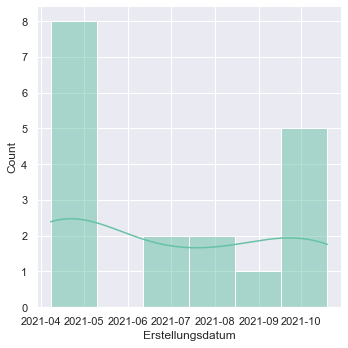

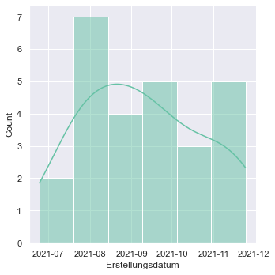

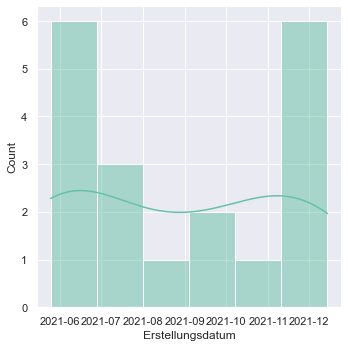

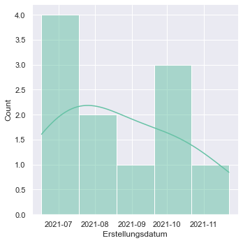

```python
# 1. Neukunden haben einen höheren Bedarf an Betreuung

es = df.dropna()[df.dropna()["Associated Company ID"].str.contains("5261525490")]
sns.displot(es, x="Erstellungsdatum", kde=True)

tu = df.dropna()[df.dropna()["Associated Company ID"].str.contains("6218292854")]
sns.displot(tu, x="Erstellungsdatum", kde=True)

hp = df.dropna()[df.dropna()["Associated Company ID"].str.contains("5898230660")]
sns.displot(hp, x="Erstellungsdatum", kde=True)

ma = df.dropna()[df.dropna()["Associated Company ID"].str.contains("5196570220")]
sns.displot(ma, x="Erstellungsdatum", kde=True)

# Kann man so nicht sagen. Im ersten Monat klar, aber danach kann man das nicht pauschal sagen.
```

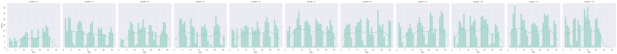

```python
# 2. Neue Releases (immer am Mittwoch) spiegeln sich in den Anfragen wieder
# 3. UVA-Fristen sind erkennbar

df['month'] = pd.DatetimeIndex(df['Erstellungsdatum']).month
df['day'] = pd.DatetimeIndex(df['Erstellungsdatum']).day

sns.displot(df, x="day", col="month", kde=True, bins=31)

# Kann so auch nicht bestätigt werden, weil die Verteilung jeden Monat anders aussieht
```

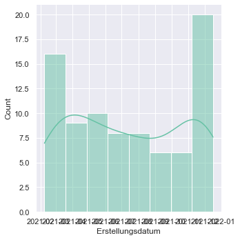

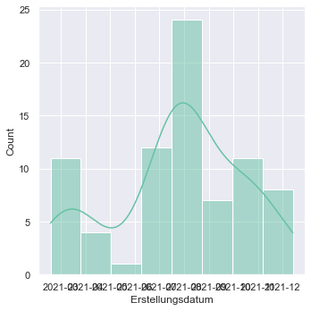

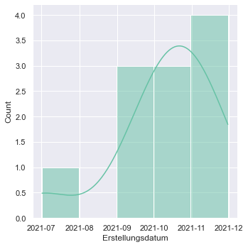

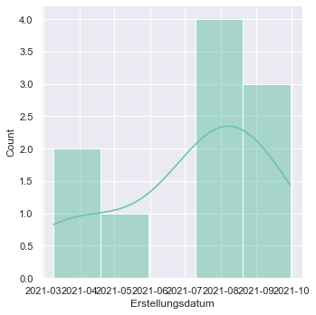

```python
# 4. LE Kunden haben einen konstanten Bedarf

wn = df.dropna()[df.dropna()["Associated Company ID"].str.contains("5226545886")]
sns.displot(wn, x="Erstellungsdatum",kde=True)

bw = df.dropna()[df.dropna()["Associated Company ID"].str.contains("5190383493")]
sns.displot(bw, x="Erstellungsdatum",kde=True)

sm = df.dropna()[df.dropna()["Associated Company ID"].str.contains("5693885810")]
sns.displot(sm, x="Erstellungsdatum",kde=True)

gc = df.dropna()[df.dropna()["Associated Company ID"].str.contains("5254502590")]
sns.displot(gc, x="Erstellungsdatum",kde=True)


# Kann leider auch nicht bestätigt werden, weil das offensichtlich all over the place ist. Haben aber auch nur wenige LEs.
```

```python
# 5. Zusammenhang Score und Dauer bis zur Schließung


df_time = df_score['Zeit bis zum Schließen (HH:mm:ss)'].str.split(':')
df_score["time in minutes"] = df_time.apply(lambda x: int(x[0]) * 60 + int(x[1]))


mean_score = df_score["Letzte CES-Umfragebewertung"].mean()
median_score = df_score["Letzte CES-Umfragebewertung"].median()
print("Durchschnittlicher Score: " + str(mean_score))
print("Median Score: " + str(median_score))
```

```
Durchschnittlicher Score: 5.938110749185668
Median Score: 7.0
```

```
<class 'pandas.core.frame.DataFrame'>
Int64Index: 286 entries, 236 to 4458
Data columns (total 7 columns):
 #   Column                             Non-Null Count  Dtype
---  ------                             --------------  -----
 0   Ticket ID                          286 non-null    int64
 1   Zeit bis zum Schließen (HH:mm:ss)  286 non-null    object
 2   Letzte CES-Umfragebewertung        286 non-null    float64
 3   Letztes CES-Umfragedatum           286 non-null    datetime64[ns]
 4   Kategorie                          286 non-null    object
 5   Associated Company ID              286 non-null    object
 6   time in minutes                    286 non-null    int64
dtypes: datetime64[ns](1), float64(1), int64(2), object(3)
memory usage: 17.9+ KB
None
```

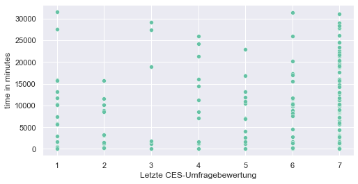

```python
def outlier_removal(df, variable):
    upper_limit = df[variable].mean() + 3 * df[variable].std()
    lower_limit = df[variable].mean() - 3 * df[variable].std()
    return upper_limit, lower_limit

# Outlier entfernen
upper_limit, lower_limit = outlier_removal(df_score, "time in minutes")
df_score = df_score[(df_score["time in minutes"] > 0) & (df_score["time in minutes"] < upper_limit)]

# Scatterplot
sns.scatterplot(x="Letzte CES-Umfragebewertung", y="time in minutes", data=df_score)

print(df_score.info())
```

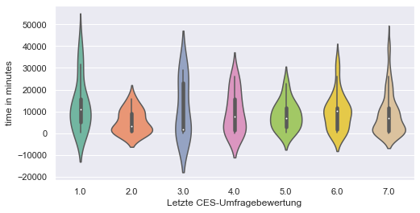

```python
ax = sns.violinplot(x="Letzte CES-Umfragebewertung", y="time in minutes", data=df_score)
```

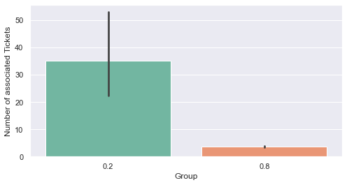

```python
# 6. Pareto-Prinzip gilt

x = sns.barplot(x="Group", y="Number of associated Tickets", data=ku)

# Das Pareto-Prinzip gilt
```

**Lessons Learned**

- Datenqualität:

In meinem Beispiel hat sich gezeigt, dass die Datenqualität wie immer sehr wichtig ist. Ich habe noch einiges an Zeit damit verbracht die Daten zu sichten, Pflegen und zu reduzieren. Leider sind teilweise missing values drinnen und teilweise komische Daten-Typen.

- Seaborn vs. andere Tools:

An sich finde ich Seaborn gut, weil es recht simpel aufgebaut ist. Aber wenn ich es mit anderen tools vergleiche, wie Power Bi, würde ich das Projet eher damit machen. Kleinigkeiten kosten oft Zeit und der Return on Investment ist hier nicht so groß.

- Weniger ist manchmal mehr:

Ich hab im letzten Beispiel einen Pareto-Chart machen wollen, aber das hat dann nach viel experimentieren nicht so gut funktioniert, wie dieser simple Bar-Chart.